# **Chapter 8. ggplot2**

Throughout the book, we will be creating plots using the ***ggplot2** package.

```r
library(dplyr)
library(ggplot2)
```

## **8.1 The components of a graph**

**ggplot2 components**

```r
library(dslabs)
data(murders)
```

## **8.2 `ggplot` objects**

The first step in creating a ggplot2 graph is to define a `ggplot` object.

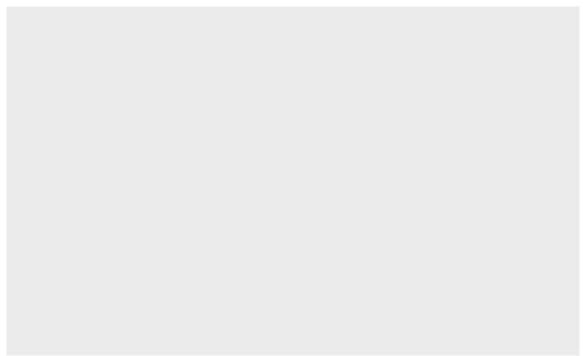

```r
ggplot(data=murders)
```

We can assign our plot to an object, for example like this:

```r
p <- ggplot(data=murders)
class(p)
```

```
[1] "gg"     "ggplot"
```

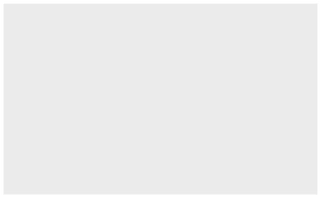

```r
print(p)
```

## **8.3 Geometries**

In `ggplot2` we create graphs by adding *layers*.

> DATA %>% ggplot() + LAYER 1 + LAYER 2 + … + LAYER N

Taking a quick look at the cheat sheet, we see that the function used to create plots with this geometry is `geom_point`.

Geometry function names follow the pattern: `geom_X` where X is the name of the geometry. Some examples include `geom_point`, `geom_bar` and `geom_histogram.`

## **8.4 Aesthetic mappings**

**Aesthetic mappings** describe how properties of the data connect with features of the graph, such as distance along an axis, size or color. The `aes` function connects data with what we see on the graph by defining aesthetic mappings.

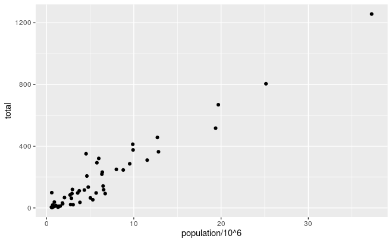

```r
murders %>% ggplot() +
  geom_point(aes(x=population/10^6, y=total))
```

앞서 `p`를 `p <- gglot(data=murders)`로 지정했기 때문에 `p`를 이용해도 된다.

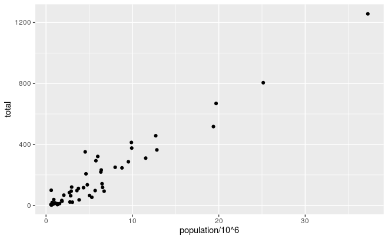

```r
p + geom_point(aes(population/10^6, total))
```

## **8.5 Layers**

A second layer in the plot we wish to make involves adding a label to each point to identify the state. The `geom_label` and `geom_text` functions permit us to add text to the plot with and without a rectangle behind the text respectively.

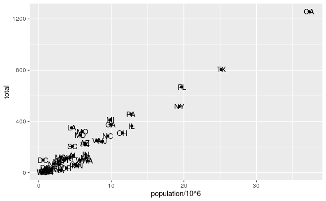

```r
p + geom_point(aes(population/10^6, total)) +
  geom_text(aes(population/10^6, total, label = abb))
```

```r
p_test <- p + geom_text(aes(population/10^6, total, label = abb))
# 이렇게 넣을 때 주의할 점은 label=abb가 aes()안에 들어있어야 한다는 것이다.
```

### **8.5.1 Tinkering with arguments**

In the plot we wish to make, the points are larger than the default size. In the help file we see that `size` is an aesthetic and we can change it like this:

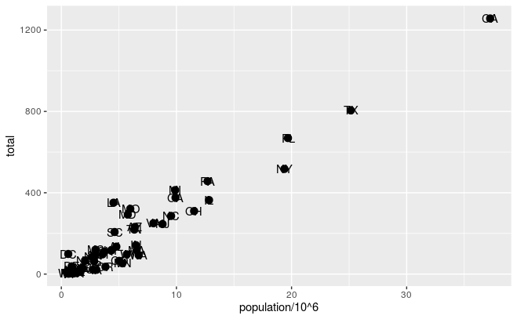

```r
p + geom_point(aes(population/10^6, total), size = 3) +
  geom_text(aes(population/10^6, total, label = abb))
```

```r
#size는 mapping이 아니기 때문에 aes()안에 포함되지 않아도 된다.
```

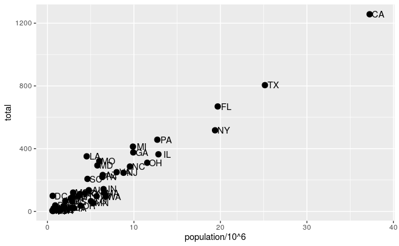

```r
p + geom_point(aes(population/10^6, total), size = 3) +
  geom_text(aes(population/10^6, total, label = abb), nudge_x = 1)
```

```r
#label을 보기 어렵기 때문에 x축으로 1만큼 옮겨준다. `nudge_x`
```

## **8.6 Global versus local aesthetic mappings**

In the previous line of code, we define the mapping `aes(population/10^6, total)` twice, once in each geometry. We can avoid this by using a global aesthetic mapping. We can do this when we define the blank slate `ggplot` object.

```r
args(ggplot)
```

```
function (data = NULL, mapping = aes(), ..., environment = parent.frame())
NULL
```

If we define a mapping in `ggplot`, all the geometries that are added as layers will default to this mapping. We redefine `p`:

```r
p <- murders %>% ggplot(aes(population/10^6, total, label = abb))
```

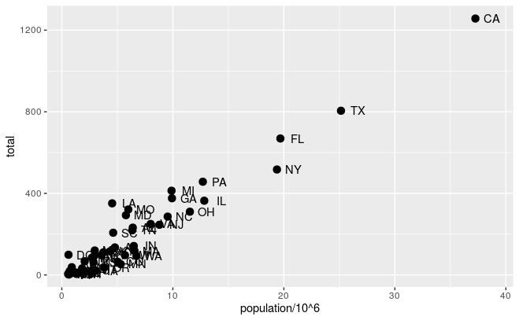

```r
p + geom_point(size = 3) +
  geom_text(nudge_x = 1.5)
```

If necessary, we can override the global mapping by defining a new mapping within each layer. These *local* definitions override the *global*. Here is an example:

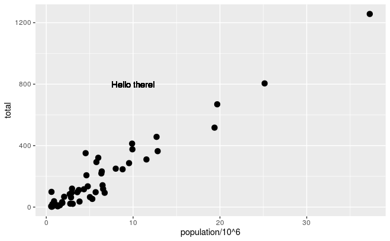

```r
p + geom_point(size = 3) +
  geom_text(aes(x = 10, y = 800, label = "Hello there!"))
```

결과적으로 `geom_text`sms `population`과 `total`을 사용하지 않는다는 것을 알 수 있다.

## **8.7 Scales**

First, our desired scales are in **log-scale**. This is not the default, so this change needs to be added through a scales layer. A quick look at the cheat sheet reveals the `scale_x_continuous` function lets us control the behavior of scales. We use them like this:

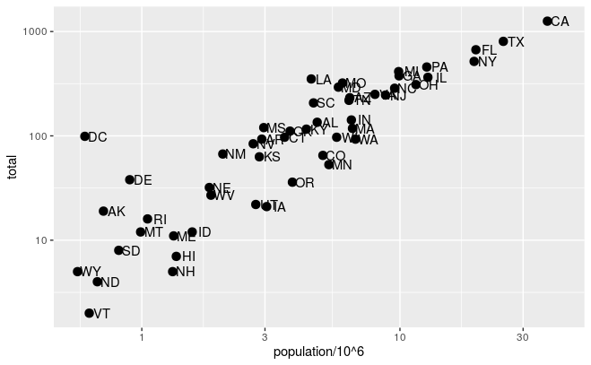

```r
p + geom_point(size = 3) +
  geom_text(nudge_x = 0.05) +
  scale_x_continuous(trans = "log10") +
  scale_y_continuous(trans = "log10")
```

This particular transformation is so common that **ggplot2** provides the specialized functions `scale_x_log10` and `scale_y_log10`, which we can use to rewrite the code like this:

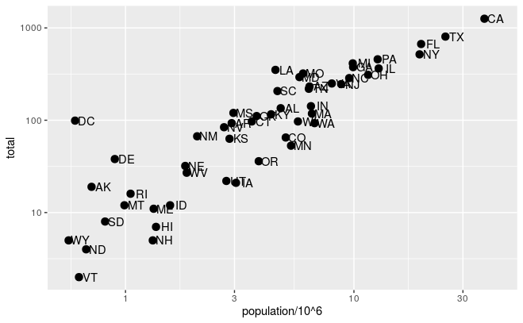

```r
p + geom_point(size = 3) +
  geom_text(nudge_x = 0.05) +
  scale_x_log10() +
  scale_y_log10()
```

## **8.8 Labels and titles**

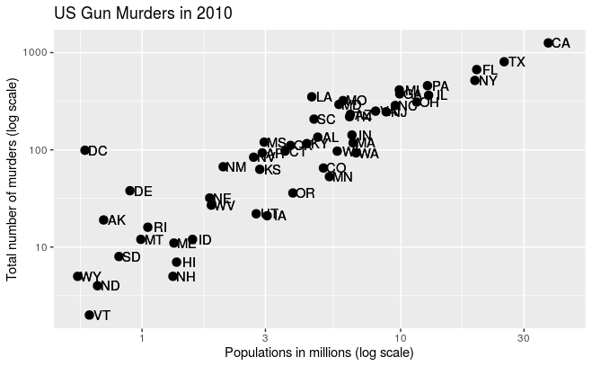

```r
p + geom_point(size = 3) +
  geom_text(nudge_x = 0.05) +
  scale_x_log10() +
  scale_y_log10() +
  xlab("Populations in millions (log scale)") +
  ylab("Total number of murders (log scale)") +
  ggtitle("US Gun Murders in 2010")
```

```r
# xlab은 x축 label, ylab은 y축 label, ggtitle은 ggplot의 title을 의미한다.
```

## **8.9 Categories as colors**

We can change the color of the points using the col argument in the `geom_point` function.

```r
p <-  murders %>% ggplot(aes(population/10^6, total, label = abb)) +
  geom_text(nudge_x = 0.05) +
  scale_x_log10() +
  scale_y_log10() +
  xlab("Populations in millions (log scale)") +
  ylab("Total number of murders (log scale)") +
  ggtitle("US Gun Murders in 2010")
```

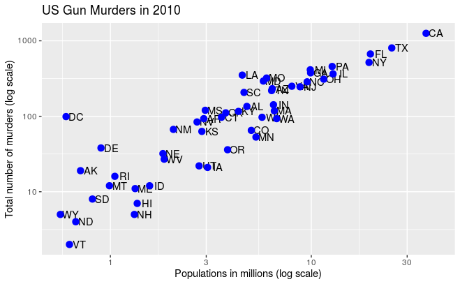

```r
p + geom_point(size = 3, color ="blue")
```

```r
# `color`을 이용해 geom_point의 색을 바꿔준다.
```

A nice default behavior of **ggplot2** is that if we assign a categorical variable to color, it automatically assigns a different color to each category and also adds a legend.

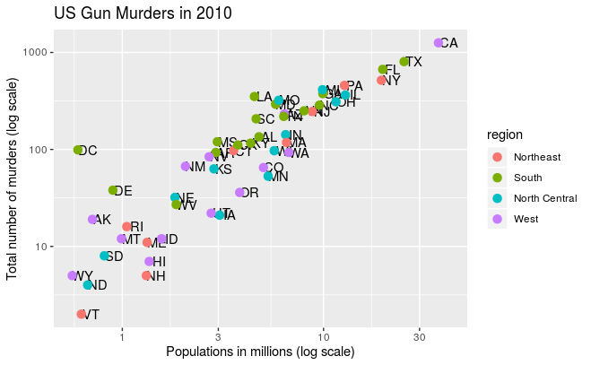

```r
p + geom_point(aes(col=region), size = 3)
```

## **8.10 Annotation, shapes, and adjustments**

Here we want to add a line that represents the average murder rate for the entire country. Once we determine the per million rate to be *r*, this line is defined by the formula:
$$y=rx$$
In the log-scale this line turns into:
$$log(y)=log(r)+log(x)$$
To compute this value, we use our dplyr skills:

```r
r <- murders %>%
  summarize(rate = sum(total) /  sum(population) * 10^6) %>%
  pull(rate)
```

To add a line we use the `geom_abline` function.

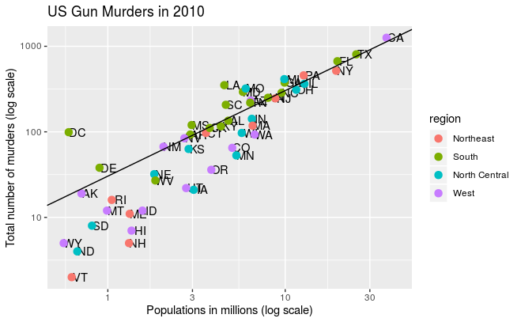

```r
p + geom_point(aes(col=region), size = 3) +
  geom_abline(intercept = log10(r))
```

We can change the line type and color of the lines using arguments.

```r
p <- p + geom_abline(intercept = log10(r), lty = 2, color = "darkgrey") +
  geom_point(aes(col=region), size = 3)
```

For example, we can make changes to the legend via the `scale_color_discrete` function.

```r
p <- p + scale_color_discrete(name = "Region")
```

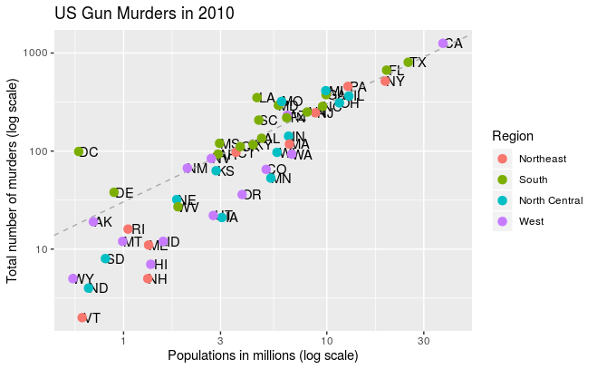

```r
print(p)
```

## **8.11 Add-on packages**

The style of a ggplot2 graph can be changed using the `theme` functions. We use a function in the dslabs package that automatically sets a default theme:

```r
ds_theme_set()
```

Many other themes are added by the package **ggthemes**. Among those are the `theme_economist` theme that we used.

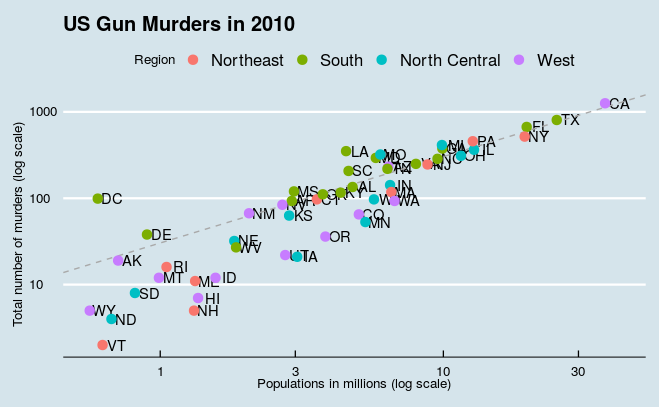

## **8.12 Putting it all together**

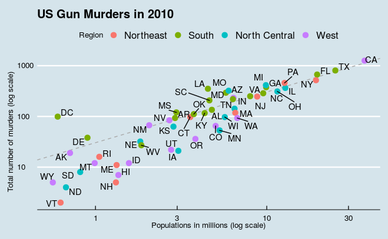

```r
library(ggthemes)
install.packages("ggrepel")
library(ggrepel)
#앞서 배운 code를 한번에 정리해서 적으면 다음과 같다.
r <- murders %>%
  summarize(rate = sum(total) /  sum(population) * 10^6) %>%
  pull(rate)

murders %>% ggplot(aes(population/10^6, total, label = abb)) +
  geom_abline(intercept = log10(r), lty = 2, color = "darkgrey") +
  geom_point(aes(col=region), size = 3) +
  geom_text_repel() +
  scale_x_log10() +
  scale_y_log10() +
  xlab("Populations in millions (log scale)") +
  ylab("Total number of murders (log scale)") +
  ggtitle("US Gun Murders in 2010") +
  scale_color_discrete(name = "Region") +
  theme_economist()
```

## **8.13 Quick plots with `qplot`**

We demonstrated how to generate these plots with `hist`, `plot`, and `boxplot.` However, if we want to keep consistent with the ggplot style, we can use the function `qplot`.

```r
data(murders)
x <- log10(murders$population)
y <- murders$total
```

We want to make a scatterplot with ggplot, we would have to type something like:

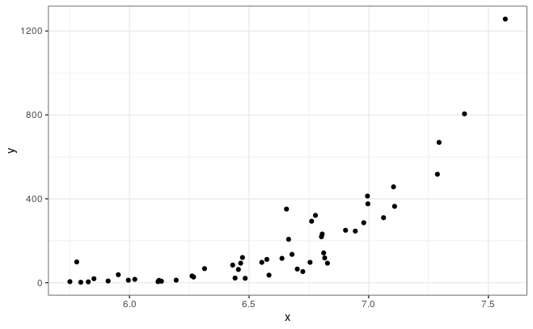

```r
data.frame(x = x, y = y) %>%
  ggplot(aes(x, y)) +
  geom_point()
```

The `qplot` function sacrifices the flexibility provided by the `ggplot` approach, but allows us to generate a plot quickly.

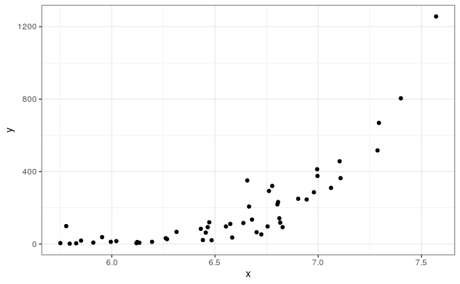

```r
qplot(x, y)
```

## **8.14 Grids of plots**

The **gridExtra** package permits us to graph plots next to each other.

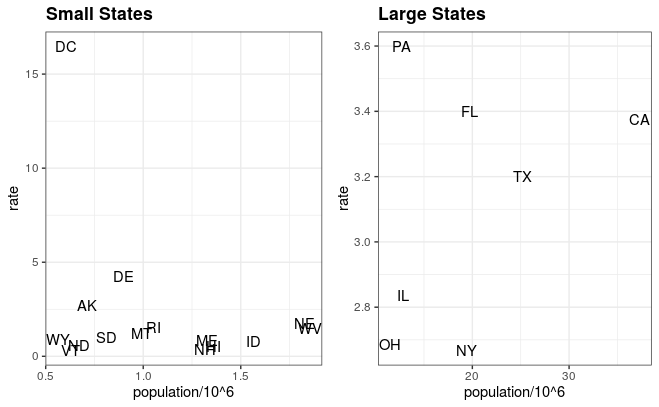

```r
install.packages("gridExtra")
library(gridExtra)
p1 <- murders %>%
  mutate(rate = total/population*10^5) %>%
  filter(population < 2*10^6) %>%
  ggplot(aes(population/10^6, rate, label = abb)) +
  geom_text() +
  ggtitle("Small States")

p2 <- murders %>%
  mutate(rate = total/population*10^5) %>%
  filter(population > 10*10^6) %>%
  ggplot(aes(population/10^6, rate, label = abb)) +
  geom_text() +
  ggtitle("Large States")

grid.arrange(p1, p2, ncol = 2)
```

## **8.15 Exercises**

Start by loading the **dplyr** and **ggplot2** library as well as the `murders` and `heights` data.

```r
library(dplyr)
library(ggplot2)
library(dslabs)
data(heights)
data(murders)
```

**1. With ggplot2 plots can be saved as objects. For example we can associate a dataset with a plot object like this**

```r
p <- ggplot(data = murders)
```

Because `data` is the first argument we don’t need to spell it out

```r
p <- ggplot(murders)
```

and we can also use the pipe:

```r
p <- murders %>% ggplot()
```

**What is class of the object `p`?**

```r
class(p)
```

```
[1] "gg"     "ggplot"
```

**2. Remember that to print an object you can use the command print or simply type the object.** For example

```r
x <- 2
x
```

```
[1] 2
```

```r
print(x)
```

```
[1] 2
```

**Print the object `p` defined in exercise one and describe what you see.**

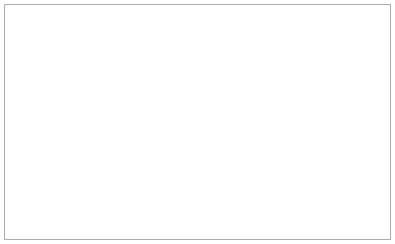

```r
print(p)
```

A. Nothing happens.

**B. A blank slate plot.**

C. A scatter plot.

D. A histogram.

**3. Using the pipe `%>%`, create an object `p` but this time associated with the `heights` dataset instead of the murders dataset.**

```r
p <- heights %>% ggplot()
```

**4. What is the class of the object p you have just created?**

```r
class(p)
```

```
[1] "gg"     "ggplot"
```

**5. Now we are going to add a layers and the corresponding aesthetic mappings. For the murders data we plotted total murders versus population sizes. Explore the `murders` data frame to remind yourself what are the names for these two variables and select the correct answer. Hint: Look at `?murders`.**

```r
head(murders)
```

|  | state | abb | region | population | total |
| --- | --- | --- | --- | --- | --- |
| 1 | Alabama | AL | South | 4779736 | 135 |
| 2 | Alaska | AK | West | 710231 | 19 |
| 3 | Arizona | AZ | West | 6392017 | 232 |
| 4 | Arkansas | AR | South | 2915918 | 93 |
| 5 | California | CA | West | 37253956 | 1257 |
| 6 | Colorado | CO | West | 5029196 | 65 |

A. `state` and `abb`.

B. `total_murders` and `population_size`.

**C. `total` and `population`.**

D. `murders` and `size`.

**6. To create the scatter plot we add a layer with `geom_point`. The aesthetic mappings require us to define the x-axis and y-axis variables respectively. So the code looks like this except we have to define the two variables x and y. Fill this out with the correct variable names**

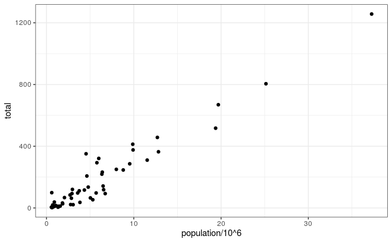

```r
murders %>% ggplot(aes(x = population/10^6 , y = total)) +
  geom_point()
```

**7. Note that if we don’t use argument names, we can obtain the same plot by making sure we enter the variable names in the right order like this:**

```r
murders %>% ggplot(aes(population, total)) +
  geom_point()
```

**Remake the plot but now with total in the x-axis and population in the y-axis.**

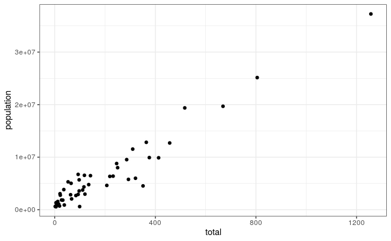

```r
murders %>% ggplot(aes(total, population)) +
  geom_point()
```

**8. If instead of points we want to add text, we can use the `geom_text()` or `geom_label()` geometries. The following code**

```r
murders %>% ggplot(aes(population, total)) +
  geom_label()
```

```
Error: geom_label requires the following missing aesthetics: label
```

**will give us the error message: `Error: geom_label requires the following missing aesthetics: label` Why is this?**

**A. We need to map a character to each point through the label argument in aes.**

B. We need to let `geom_label` know what character to use in the plot.

C. The `geom_label` geometry does not require x-axis and y-axis values.

D. `geom_label` is not a ggplot2 command.

**9. Rewrite the code above to abbreviation as the label through `aes`**

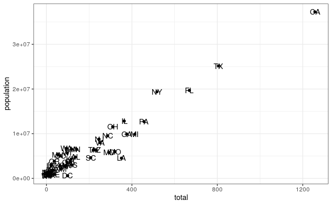

```r
murders %>% ggplot(aes(total, population)) +
  geom_point() + geom_text(aes(total, population, label=abb))
```

**10. Change the color of the labels through blue. How will we do this?**

A. Adding a column called `blue` to `murders`

B. Because each label needs a different color we map the colors through `aes`

C. Use the `color` argument in `ggplot`

D. Because we want all colors to be blue, we do not need to map colors, just use the color argument in `geom_label`

**11. Rewrite the code above to make the labels blue.**

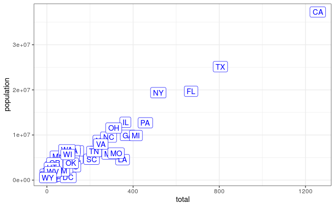

```r
murders %>% ggplot(aes(total, population)) +
  geom_point() + geom_text(aes(total, population, label=abb)) + geom_label(aes(label=abb), color = "blue")
```

**12. Now suppose we want to use color to represent the different regions. In this case which of the following is most appropriate:**

A. Adding a column called `color` to `murders` with the color we want to use.

**B. Because each label needs a different color we map the colors through the color argument of `aes`.**

C. Use the `color` argument in `ggplot`.

D. Because we want all colors to be blue, we do not need to map colors, just use the color argument in `geom_label`.

**13. Rewrite the code above to make the labels’ color be determined by the state’s region.**

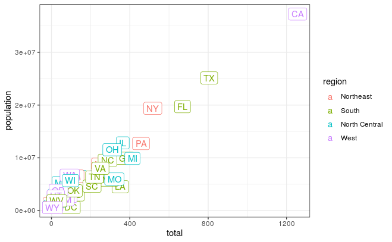

```r
murders %>% ggplot(aes(total, population)) +
  geom_point() + geom_text(aes(total, population, label=abb)) + geom_label(aes(label=abb, col=region))
```

**14. Now we are going to change the x-axis to a log scale to account for the fact the distribution of population is skewed. Let’s start by define an object `p` holding the plot we have made up to now**

```r
p <- murders %>%
  ggplot(aes(population, total, label = abb, color = region)) +
  geom_label()
```

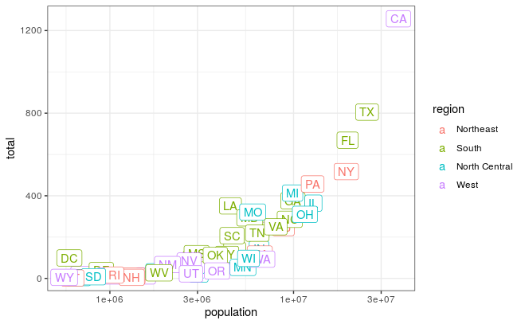

```r
p+ scale_x_log10()
```

**15. Repeat the previous exercise but now change both axes to be in the log scale.**

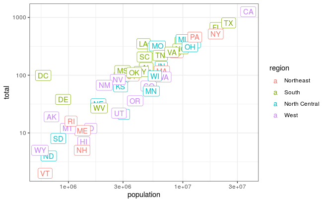

```r
p+ scale_x_log10() + scale_y_log10()
```

**16. Now edit the code above to add the title “Gun murder data” to the plot. Hint: use the `ggtitle` function.**

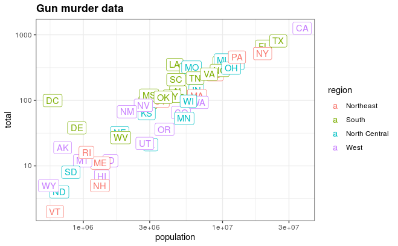

```r
p + scale_x_log10() + scale_y_log10() + ggtitle("Gun murder data")
```